## 0.1 Should Blackwell acquire Electronidex

```r
#load libraries
library(dplyr)
library(tidyr)
library(ggplot2)
library(RColorBrewer)
library(tibble)
library(arules)
library(arulesViz)
library(caret)
library(readr)
library(pdftools)
library(stringr)
library(gridExtra)
library(kableExtra)
library(treemap)
```

```r
#load csv data
transData <- read.transactions("C:/Users/rhysh/Google Drive/Data Science/Ubiqum/Project 2/Task 4/data/ElectronidexTransactions2017.csv", format = "basket", sep = ",")
prodData <- read.csv("C:/Users/rhysh/Google Drive/Data Science/Ubiqum/Project 2/Task 4/data/ElectronidexTransactions2017.csv", header = FALSE)

#Load type data
load("C:/Users/rhysh/Google Drive/Data Science/Ubiqum/Project 2/Task 4/output/typeData.RDS")

#Load data - Blackwell products info
blackData <- read.csv("C:/Users/rhysh/Google Drive/Data Science/Ubiqum/Project 2/Task 4/data/existingProductAttributes.csv")

##Load Data - Blackwell demographics
blackDemo <- read_csv2("C:/Users/rhysh/Google Drive/Data Science/Ubiqum/Project 2/Task 4/data/Blackwell_Demographic_Data.csv")
colnames(blackDemo)[1] <- "instore"

#Load Data - profit predictions Blackwell
profPred <- read.csv("C:/Users/rhysh/Google Drive/Data Science/Ubiqum/Project 2/Task 4/data/BWNewProfitPredictions.csv")
```

Before making a recommendation as to whether to purchase Electronidex I think it would be beneficial to give an overview of both companies.

## 0.2 Blackwell Electronics

Blackwell Electronics is a successful consumer electronics retailer with over 30 stores in the southeastern United States and who last year launched an eCommerce website.

### 0.2.1 Sales & Profit

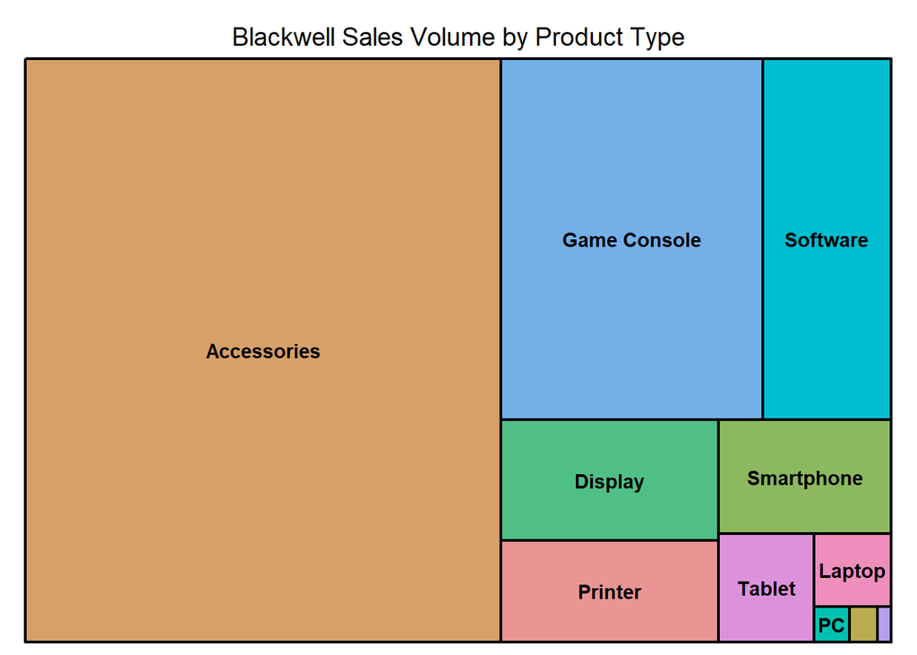

```r
blackData <- blackData %>% filter(Product.Type != "Extended Warranty") %>%
        mutate(profit = (Volume * Price * Profit.margin)/10^3, unitProfit = Price * Profit.margin)


blackProfit <- blackData %>% group_by(Product.Type) %>%
        summarise(absProfit = sum(profit), unitProfit = mean(unitProfit), volume = sum(Volume),
                  meanMargin = mean(Profit.margin), avgPrice = mean(Price))


treemap(blackProfit, index = "Product.Type", vSize = "volume", title = "Blackwell Sales Volume by Product Type")
```

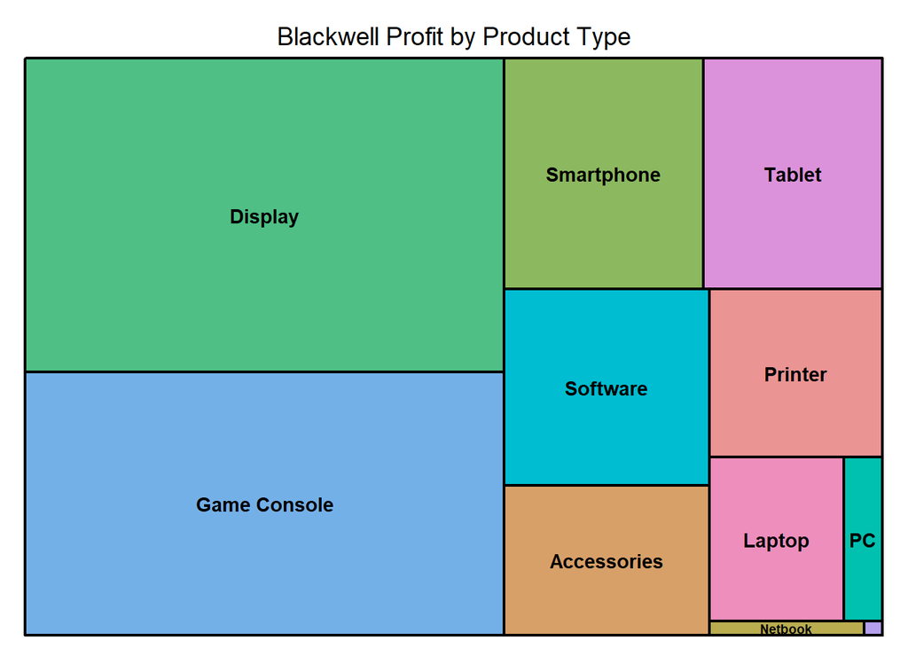

```r
treemap(blackProfit, index = "Product.Type", vSize = "absProfit", title = "Blackwell Profit by Product Type")
```

We see that in terms of sales volume, Accessories and Game Consoles make up the majority of Blackwell’s Products. Looking at the profit, however, we see that it is Games Consoles and Displays that make up a substantial part of Blackwell’s profits.

### 0.2.2 Transaction Location

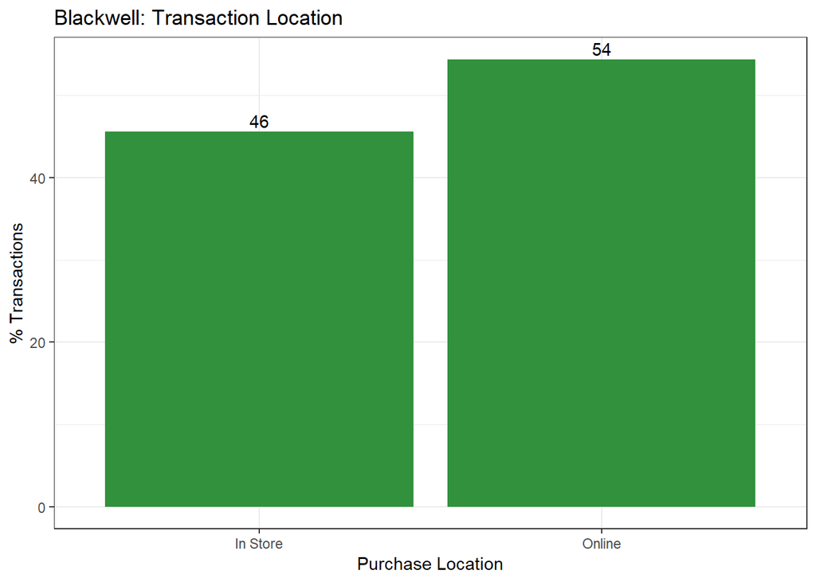

```r
#Blackwell instore v online
onlinePurch <- blackDemo %>% group_by(instore) %>%
        summarise(count = n())
onlinePurch <- onlinePurch %>% mutate(percent = (count/sum(onlinePurch$count))*100)
onlinePurch$instore[onlinePurch$instore == 0] <- "Online"
onlinePurch$instore[onlinePurch$instore == 1] <- "In Store"

g6 <- ggplot(onlinePurch, aes(instore, percent)) +
        geom_col(fill = "#31913c") +
        theme_bw() +
        ylab("% Transactions") +
        xlab("Purchase Location") +
        ggtitle("Blackwell: Transaction Location") +
        geom_text(aes(label = percent %>% round(0)), vjust = -0.3)
g6
```

We also see that whilst the majority of Blackwell transactions take place online, there is a sizeable proportion that take place in-store.

### 0.2.3 Items per Transaction

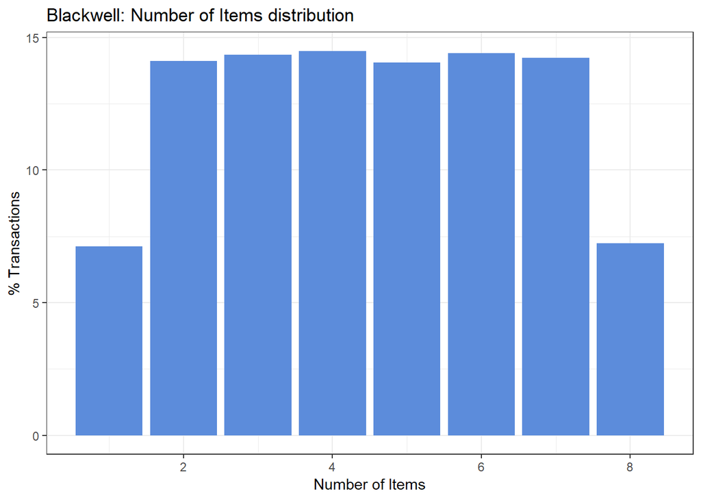

```r
#Blackwell items per purchase
numItems <- blackDemo %>% group_by(items) %>%
        summarise(num_items = n())
numItems <- numItems %>% mutate(percent = (num_items/sum(numItems$num_items))*100)

g7 <- ggplot(numItems, aes(items, percent)) +
        geom_col(fill = "#5c8cdb") +
        theme_bw() +
        ylab("% Transactions") +
        xlab("Number of Items") +
        ggtitle("Blackwell: Number of Items distribution")
g7
```

Looking at the distribution of the number of items per purchase we see that most transactions involve 2-7 items with no transactions exceeding 8 items.

### 0.2.4 Expected Profitability

```r
kable(profPred) %>%
        kable_styling(bootstrap_options = "striped", full_width = F, position = "left")
```

| ProductType | ProductNo | BrandName | Price | ProfitMargin | SalesVolume | Profit |
| --- | --- | --- | --- | --- | --- | --- |
| Tablet | 187 | Amazon | $199.00 | 0.20 | 2638 | $104,992.40 |
| PC | 171 | Dell | $699.00 | 0.25 | 282 | $49,279.50 |
| Tablet | 186 | Apple | $629.00 | 0.10 | 752 | $47,300.80 |
| Netbook | 180 | Acer | $329.00 | 0.09 | 780 | $23,095.80 |
| Game Console | 199 | Sony | $249.99 | 0.09 | 944 | $21,239.15 |

Finally, reviewing the items with the top 5 expected profitability, we see Tablets, PCs, Netbooks and Games Consoles.

## 0.3 Electronidex

Electronidex is a start-up electronics online retailer.

### 0.3.1 Estimated Sales Volume

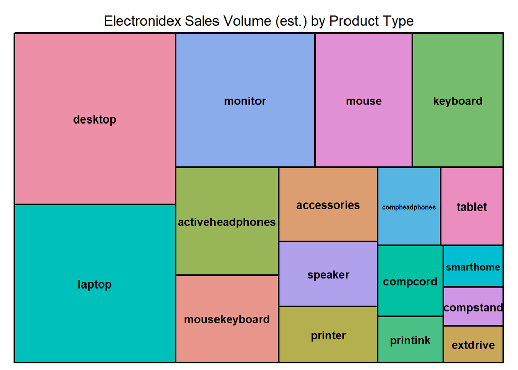

```r
electroProducts <- itemFrequency(typeData) %>% as.data.frame() %>% rownames_to_column()
names(electroProducts) <- c("ProductType", "Support")


treemap(electroProducts, index = "ProductType", vSize = "Support", title = "Electronidex Sales Volume (est.) by Product Type")
```

Using the product-type frequency we can estimate a general picture of the type of products sole by Electronidex and the approximate sales volume.

We see that Desktops, Laptops and Monitors form a large portion of their business.

### 0.3.2 Estimated Items per Transaction

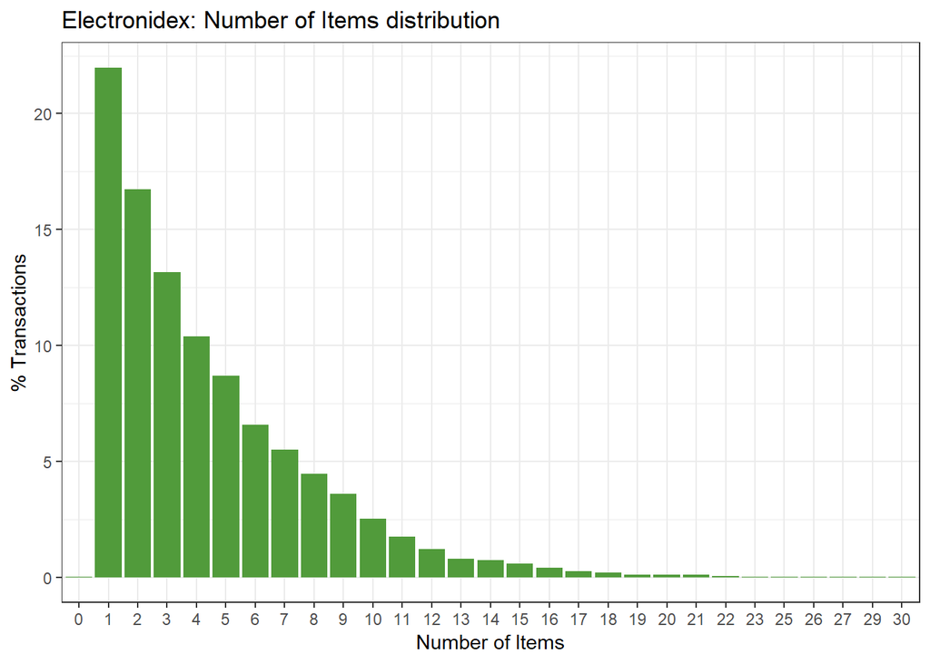

```r
#Electronidex items per purchase
sizeTrans <- size(transData)
transTable <- table(sizeTrans) %>% as.data.frame()
transTable <- transTable %>% mutate(percent = (Freq/sum(transTable$Freq))*100)

g8 <- ggplot(transTable, aes(sizeTrans, percent)) +
        geom_col(fill = "#519b3b") +
        theme_bw() +
        ylab("% Transactions") +
        xlab("Number of Items") +
        ggtitle("Electronidex: Number of Items distribution")
g8
```

As we only have transaction information, not sales figures, we can only make some general conclusions about numbers of items per transaction. Using the unsatisfactory metric of 1 item sold if the item is present within the transaction we can still draw somw general conclusions.

## 0.5 Blackwell SWOT Analysis

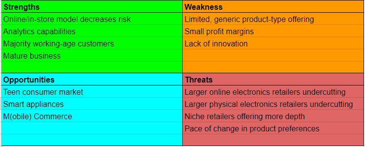